# Расчёт потерь давления (напора) в трубе

Величина потерь давления (напора) при движении в трубе потока рабочей среды характеризуется коэффициентом сопротивления трения единицы относительной длины. В прямой трубе имеются потери давления только от трения, поэтому коэффициент гидравлического сопротивления равен коэффициенту сопротивления трения: $$\zeta = \zeta_{тр} = \lambda \bar{l};\,\bar{l} = l / D;\,\Delta H = \zeta \frac{w^2}{2g};\,\,\, \Delta p = \zeta \frac{\rho w^2}{2}$$ где $\lambda$ - коэффициент сопротивления трения единицы относительной длины, $l$ - длина трубы, м; $D$ - внутренний диаметр трубы, м, $\Delta H$, $\Delta p$ - потери даления в метрах столба жидкости и в Па соответственно, $w$ - скорость движения рабочей среды, м/с; $\rho$ - плотность рабочей среды $кг/м^3$; $g = 9.80665\, м/с^2$ - ускорение свободного падения.
Потери давления от трения зависят от шероховатости внутренних стенок трубы, вязкости рабочей среды, скорости движения рабочей среды и режима течения в трубе.
Шероховатость задаётся значением относительной шероховатости: $$\bar{\Delta} = \Delta / D,$$ где $\Delta$ - абсолютная шероховатость, м.
Режим течения в трубе определяется числом Рейнольдса:
$$Re = \frac{wD}{\nu},$$ где $w$ - скорость, м/с; $\nu$ - кинематическая вязкость, $м^2/с$.

При реализации приведённой в [1] расчётной методики приняты следующие допущения:

1. Рабочая среда - вода температурой 20 С;
2. Трубы круглого сечения с неравномерной шероховатостью стенок (технические трубы) или гладкие трубы;
3. Для технических труб должно выполняться условие $Re > 2090 \cdot \bar\Delta^{-\, 0.0635} $ (стр. 88 в [1], формула для $Re_2$);
4. Для гладких труб должно выполняться условие $Re > 4000$ (стр. 85 в [1]);
5. Точка перехода течения в режим квадратичного закона сопротивления $Re = 560 / \bar{\Delta}$ (стр. 93 в [1]).

Все созданные для реализации данной расчётной методики функции включены в модуль `hydrcalc` ([скачать](https://medsv.github.io/dzen/0023/hydrcalc.py) версию 1). Пример использования основной расчётной функции `calc_dH` см.здесь. Описание всех функций модуля `hydrcalc` приведены здесь.

## Проверка корректности реализации методики расчёта гидравлического сопротивления труб

```python
import numpy as np
from hydrcalc import calc_lambda
```

```python
#Функция для тестирования и сравнения полученных результатов с данными из [1] стр. 91 - 92
def test_lamb(Re, delta):
    w = 3 #скорость, м/с
    kvisc = 1e-6 #кинематическая вязкость воды при t = 20 C, м2/с
    D = Re * kvisc / w #внутренний диаметр трубы, м
    Delta = delta * D #шероховатость стенок трубы, м
    return calc_lambda(w, D, Delta)
```

```python
#Набор чисел Рейнольдса
Res = np.array([3e3, 4e3, 6e3, 1e4, 2e4, 4e4, 6e4, 1e5, 2e5, 4e5, 6e5, 1e6, 2e6, 4e6, 1e7, 2e7, 1e8])
#Набор относительных шероховатостей
deltas = np.array([.05, .04, .03, .02, .015, .01, .008, .006, .004, .002, .001,
                   .0008, .0006, .0004, .0002, .0001, .00005, .00001, .000005 ])
lambs = np.zeros([deltas.shape[0], Res.shape[0]]) #массив для хранения результатов вычисления
for i, delta in enumerate(deltas):
    for j, Re in enumerate(Res):
        try: #чтобы не вызывать остановку выполнения при выпадении Re из допустимого диапазона
            #вычисляем коэффициент сопротивления трения единицы относительной длины
            lambs[i,j] = test_lamb(Re, delta)
        except ValueError: #если Re вне допустимого диапазона
            lambs[i,j] = None
```

```python
#Создандим таблицу для сравнения с таблицей в [1] стр. 91 - 92
import pandas as pd
columns =[]
myformat = "{:.0e}"
for Re in Res:
    columns.append(myformat.format(Re))
table = pd.DataFrame(np.round(lambs,3), index = deltas, columns = columns)
table
#Заголовки строк - относительная шероховатость, заголовки столбцов - число Рейнольдса
```

|  | 3e+03 | 4e+03 | 6e+03 | 1e+04 | 2e+04 | 4e+04 | 6e+04 | 1e+05 | 2e+05 | 4e+05 | 6e+05 | 1e+06 | 2e+06 | 4e+06 | 1e+07 | 2e+07 | 1e+08 |
| --- | --- | --- | --- | --- | --- | --- | --- | --- | --- | --- | --- | --- | --- | --- | --- | --- | --- |
| 0.050000 | 0.079 | 0.077 | 0.075 | 0.074 | 0.073 | 0.072 | 0.072 | 0.072 | 0.072 | 0.072 | 0.072 | 0.072 | 0.072 | 0.072 | 0.072 | 0.072 | 0.072 |
| 0.040000 | 0.073 | 0.071 | 0.069 | 0.067 | 0.066 | 0.065 | 0.065 | 0.065 | 0.065 | 0.065 | 0.065 | 0.065 | 0.065 | 0.065 | 0.065 | 0.065 | 0.065 |
| 0.030000 | 0.066 | 0.064 | 0.062 | 0.060 | 0.059 | 0.058 | 0.058 | 0.057 | 0.057 | 0.057 | 0.057 | 0.057 | 0.057 | 0.057 | 0.057 | 0.057 | 0.057 |
| 0.020000 | 0.059 | 0.057 | 0.054 | 0.052 | 0.051 | 0.050 | 0.049 | 0.049 | 0.049 | 0.049 | 0.049 | 0.049 | 0.049 | 0.049 | 0.049 | 0.049 | 0.049 |
| 0.015000 | 0.056 | 0.053 | 0.050 | 0.048 | 0.046 | 0.045 | 0.044 | 0.044 | 0.044 | 0.044 | 0.044 | 0.044 | 0.044 | 0.044 | 0.044 | 0.044 | 0.044 |
| 0.010000 | 0.052 | 0.049 | 0.046 | 0.043 | 0.041 | 0.039 | 0.039 | 0.039 | 0.038 | 0.038 | 0.038 | 0.038 | 0.038 | 0.038 | 0.038 | 0.038 | 0.038 |
| 0.008000 | 0.050 | 0.047 | 0.044 | 0.041 | 0.038 | 0.037 | 0.036 | 0.036 | 0.036 | 0.035 | 0.035 | 0.035 | 0.035 | 0.035 | 0.035 | 0.035 | 0.035 |
| 0.006000 | 0.049 | 0.046 | 0.042 | 0.039 | 0.036 | 0.034 | 0.033 | 0.033 | 0.033 | 0.032 | 0.032 | 0.032 | 0.032 | 0.032 | 0.032 | 0.032 | 0.032 |
| 0.004000 | 0.047 | 0.044 | 0.040 | 0.036 | 0.033 | 0.031 | 0.030 | 0.030 | 0.029 | 0.029 | 0.029 | 0.029 | 0.028 | 0.028 | 0.028 | 0.028 | 0.028 |
| 0.002000 | NaN | 0.042 | 0.038 | 0.034 | 0.030 | 0.027 | 0.026 | 0.025 | 0.024 | 0.024 | 0.024 | 0.024 | 0.024 | 0.023 | 0.023 | 0.023 | 0.023 |
| 0.001000 | NaN | 0.041 | 0.037 | 0.032 | 0.028 | 0.025 | 0.023 | 0.022 | 0.021 | 0.020 | 0.020 | 0.020 | 0.020 | 0.020 | 0.020 | 0.020 | 0.020 |
| 0.000800 | NaN | 0.041 | 0.036 | 0.032 | 0.028 | 0.024 | 0.023 | 0.021 | 0.020 | 0.019 | 0.019 | 0.019 | 0.019 | 0.019 | 0.019 | 0.019 | 0.019 |
| 0.000600 | NaN | 0.041 | 0.036 | 0.032 | 0.027 | 0.024 | 0.022 | 0.021 | 0.019 | 0.018 | 0.018 | 0.018 | 0.018 | 0.018 | 0.017 | 0.017 | 0.017 |
| 0.000400 | NaN | 0.040 | 0.036 | 0.031 | 0.027 | 0.023 | 0.022 | 0.020 | 0.018 | 0.017 | 0.017 | 0.016 | 0.016 | 0.016 | 0.016 | 0.016 | 0.016 |
| 0.000200 | NaN | 0.040 | 0.036 | 0.031 | 0.026 | 0.023 | 0.021 | 0.019 | 0.017 | 0.016 | 0.015 | 0.015 | 0.014 | 0.014 | 0.014 | 0.014 | 0.014 |
| 0.000100 | NaN | 0.040 | 0.036 | 0.031 | 0.026 | 0.022 | 0.020 | 0.019 | 0.016 | 0.015 | 0.014 | 0.013 | 0.013 | 0.012 | 0.012 | 0.012 | 0.012 |
| 0.000050 | NaN | 0.040 | 0.036 | 0.031 | 0.026 | 0.022 | 0.020 | 0.018 | 0.016 | 0.014 | 0.013 | 0.013 | 0.012 | 0.011 | 0.011 | 0.011 | 0.011 |
| 0.000010 | NaN | NaN | 0.036 | 0.031 | 0.026 | 0.022 | 0.020 | 0.018 | 0.016 | 0.014 | 0.013 | 0.012 | 0.011 | 0.010 | 0.009 | 0.009 | 0.008 |
| 0.000005 | NaN | NaN | 0.036 | 0.031 | 0.026 | 0.022 | 0.020 | 0.018 | 0.016 | 0.014 | 0.013 | 0.012 | 0.011 | 0.010 | 0.009 | 0.008 | 0.007 |

```python
import matplotlib.pyplot as plt
#Настройки, общие для всех графиков
plt.rcParams['font.size'] = 12
plt.rcParams['axes.grid'] = True
plt.rcParams['legend.shadow'] = False
plt.rcParams['figure.figsize'] = (11,5)
```

```python
#Построим зависимость коэффициента сопротивления трения единицы
#относительной длины от внутреннего диаметра трубы
Deltas = np.array([0, 0.1, 0.2, 0.3, 0.4, 0.5]) * 1e-3 #абсолютная шероховатость труб, м
kvisc = 1e-6 #кинематическая вязкость (вода при 20 С)
w = 2 #скорость рабочей среды
Ds = np.linspace(40, 200, 101)
lambs = np.zeros((Deltas.shape[0], Ds.shape[0]), dtype = float)
for i, Delta in enumerate(Deltas):
    for j, D in enumerate(Ds):
        D /= 1e3
        lambs[i,j] = calc_lambda(w, D, Delta)
```

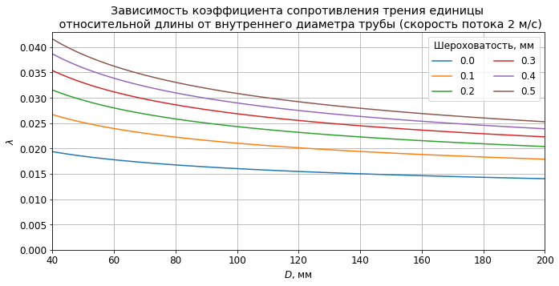

```python
fig, ax = plt.subplots(figsize = (11,5))
for i, Delta in enumerate(Deltas):
    ax.plot(Ds, lambs[i,:], label = Delta * 1e3)
ax.set_xlim(40, 200); ax.set_ylim(0,)
ax.set_xlabel("$D$, мм"); ax.set_ylabel("$\lambda$")
ax.legend(ncol=2, title="Шероховатость, мм")
ax.set_title('Зависимость коэффициента сопротивления трения единицы \n \
относительной длины от внутреннего диаметра трубы (скорость потока 2 м/с)');
```

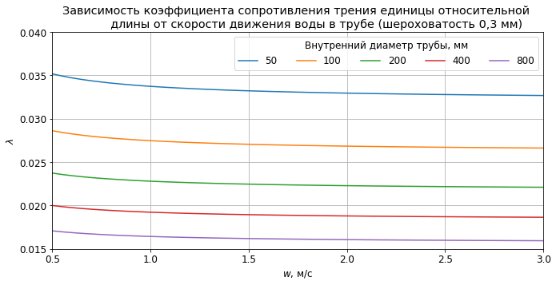

```python
#Построим зависимость коэффициента сопротивления трения единицы
#относительной длины от скорости движения воды в трубе
Delta = 0.3e-3
ws = np.linspace(0.5, 3, 51)
Ds = np.array([50, 100, 200, 400, 800])
#deltas = Delta / (Ds / 1000)
lambs = np.zeros((Ds.shape[0], ws.shape[0]), dtype = float)
for i, D in enumerate(Ds):
    D /= 1e3
    for j, w in enumerate(ws):
        lambs[i,j] = calc_lambda(w, D, Delta)
        #Re[i,j] = fRe(w, D, kvisc)
fig, ax = plt.subplots()
for i, D in enumerate(Ds):
    ax.plot(ws, lambs[i,:], label = D)
ax.set_xlim(0.5, 3); ax.set_ylim(0.015,0.04)
ax.legend(ncol=5, title = 'Внутренний диаметр трубы, мм')
ax.set_xlabel("$w$, м/c"); ax.set_ylabel("$\lambda$")
ax.set_title("Зависимость коэффициента сопротивления трения единицы относительной \n \
         длины от скорости движения воды в трубе (шероховатость 0,3 мм)");
```

## Учёт перехода к режиму квадратичного закона сопротивления

Согласно стр. 92 в [1] при $Re > 560 / \bar{\Delta}$ течение жидкости переходит в режим квадратичного закона сопротивления.

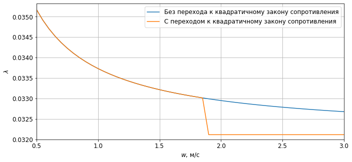

```python
#Построим зависимость коэффициента сопротивления трения единицы
#относительной длины от скорости движения воды в трубе с параметром функции calc_lambda
#quadr со значением False (без перехода к квадратичному закону сопротивления,
#по умолчанию) и quadr=True (с переходом к квадратичному закону сопротивления)
D = 50e-3 # внутренний диаметр трубы, м
Delta = 0.3e-3 # шероховатость, м
lambs = np.zeros_like(ws) #результат расчёта без перемены формулы при Re>Re_кв (стр. 90 в [1])
lambqs = np.zeros_like(ws) #результат расчёта с переменой формулы при Re>Re_кв (стр. 92 в [1])
for i, w in enumerate(ws):
    lambs[i] = calc_lambda(w, D, Delta)
    lambqs[i] = calc_lambda(w, D, Delta, quadr = True)
fig, ax = plt.subplots()
ax.plot(ws, lambs, label = 'Без перехода к квадратичному закону сопротивления')
ax.plot(ws, lambqs, label = 'С переходом к квадратичному закону сопротивления')
ax.set_xlim(0.5, 3); ax.set_ylim(0.032, )
ax.set_xlabel("$w$, м/c"); ax.set_ylabel("$\lambda$")
plt.legend();
```

Режим квадратичного закона сопротивления возникает при $$Re_{кв} = \frac{560}{\bar{\Delta}} $$ Найдём выражение для скорости, при которой возникает режим квадратичного закона сопротивления

$$Re_{кв} = \frac{560 D}{\Delta};\, Re_{кв} = \frac{w_{кв}D}{\nu};\, w_{кв} = \frac{560\nu}{\Delta}$$

В модуле `hydrcalc` есть функция `calc_w_q(Delta, kvisc)`, которая возвращает значение скорости, при котором течение переходит в режим квадратичного закона сопротивления.

```python
from hydrcalc import calc_w_q
```

```python
#Определим относительную разницу в результах расчёта по разным формулам при Re > Re_кв
Deltas = np.array([0.1, 0.2, 0.3, 0.4, 0.5]) * 1e-3 #абсолютная шероховатость стенок, м
kvisc = 1e-6 #кинематическая вязкость (вода при 20 С), м/с2
Ds = np.linspace(20, 1400, 101) #внутренние диаметры труб, мм
#Относительная разница результатов расчётов в процентах
errs = np.zeros((Deltas.shape[0], Ds.shape[0]), dtype = float)
for i, Delta in enumerate(Deltas):
    wq = calc_w_q(Delta, kvisc) * 1.0001
    for j, D in enumerate(Ds):
        D /= 1e3 # перевод в метры
        lamb = calc_lambda(wq, D, Delta)
        lambq = calc_lambda(wq, D, Delta, quadr = True)
        errs[i,j] = (lamb/lambq -1 ) * 100
```

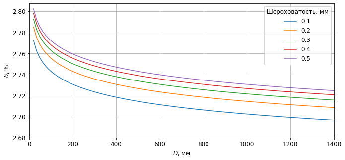

```python
fig, ax = plt.subplots()
for i, Delta in enumerate(Deltas):
    ax.plot(Ds, errs[i][:], label = Delta * 1e3)
ax.set_xlim(0, 1400); ax.set_ylim(2.68, )
ax.legend(title="Шероховатость, мм")
ax.set_xlabel("$D$, мм"); ax.set_ylabel("$\delta$, %");
```

С параметром `quadr = False` (по умолчанию) функция `calc_lambda` при $Re > 560 D/\bar{\Delta}$ будет возвращать значение $\lambda$ на 3% больше по сравнению с формулой на стр. 92 в [1] для режима квадратичного закона сопротивления.

### Режим квадратичного закона сопротивления (стр. 93 в [1])

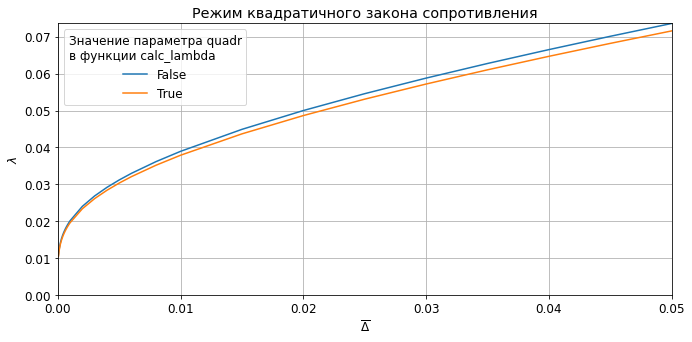

```python
deltas = [.00005, .0001, .0002, .0003, .0004, .0005, .0006, .0007, .0008, .0009, .001, .002, .003,
         .004, .005, .006, .008, .01, .015, .020, .025, .03, .035, .04, .045, .05]
lambs = []
lambsq = []
D = 100.
for i, delta in enumerate(deltas):
    Delta = delta * D
    wq = calc_w_q(Delta, kvisc) * 1.0001
    lambs.append(calc_lambda(wq, D, Delta))
    lambsq.append(calc_lambda(wq, D, Delta, quadr = True))
fig, ax = plt.subplots()
ax.set_xlim(0., .05); ax.set_ylim(0.,lambs[-1])
ax.plot(deltas, lambs, label = 'False')
ax.plot(deltas, lambsq, label = 'True')
ax.legend(title="Значение параметра quadr\nв функции calc_lambda")
ax.set_xlabel("$\overline{\Delta}$"); ax.set_ylabel("$\lambda$")
ax.set_title("Режим квадратичного закона сопротивления");
```

## Пример использования функции `calc_dH`

```python
from hydrcalc import calc_dH
```

```python
D_внешн = 89 #внешний диаметр трубы, мм
h = 3.5 #толщина стенки трубы, мм
D = D_внешн - 2 * h #внутренний диаметр, мм
D *= 1e-3 #перевод в метры
Q = 50 #объёмный расход, м3/ч
L = 100 #длина трубопровода, м
Delta=0.3e-3 #шероховатость стенок трубы, м
```

```python
dH = calc_dH(Q, D, L, Delta=0)
print(f"Потери давления на {L} метрах трубы {D_внешн}х{h} с шероховатостью стенок {Delta*1e3} мм " +
      f"при расходе {Q} м3/ч составляют {round(dH, 1)} метров водяного столба.")
```

[output not shown]

## Описание всех функций модуля `hydrcalc`

```python
import hydrcalc
help(hydrcalc)
```

```
Help on module hydrcalc:

NAME
    hydrcalc

DESCRIPTION
    В модуле размещёны функции для расчёта коэффициентов гидравлического сопротивления следующих элементов трубопровода:
    1. Прямые круглые трубы (гладкие и с неравномерной шероховатостью)

FUNCTIONS
    calc_Re(w, D, kvisc=1e-06)
        Вычисление числа Рейнольдса
        w: скорость, м/с
        D: внутренний диаметр трубы, м
        kvisc: кинематическая вязкость, м2/с (по умолчанию - вязкость воды при 20 С)

    calc_dH(Q, D, L, Delta=0, kvisc=1e-06, quadr=False)
        Расчёт потерь давления, метры столба жидкости
        Q: объёмный расход, м3/ч
        D: внутренний диаметр трубы, м
        L: длина трубы, м
        Delta: абсолютная шероховатость, м (по умолчанию - отсутствие шероховатости, гладкая труба)
        kvisc: кинематическая вязкость, м2/с (по умолчанию - вязкость воды при 20 С)
        quadr: False (по умолчанию) - не происходит смены формулы при Re>560/delta,
        True - при Re>560/delta применяется формула для квадратичного закона сопротивления

    calc_frc(Q, D, L, Delta=0, kvisc=1e-06, quadr=False)
        Расчёт коэффициента сопротивления трения
        Q: объёмный расход, м3/ч
        D: внутренний диаметр трубы, м
        L: длина трубы, м
        Delta: абсолютная шероховатость, м (по умолчанию - отсутствие шероховатости, гладкая труба)
        kvisc: кинематическая вязкость, м2/с (по умолчанию - вязкость воды при 20 С)
        quadr: False (по умолчанию) - не происходит смены формулы при Re>560/delta,
        True - при Re>560/delta применяется формула для квадратичного закона сопротивления

    calc_frc_w(w, D, L, Delta=0, kvisc=1e-06, quadr=False)
        Расчёт коэффициента сопротивления трения
        w: скорость, м/с
        D: внутренний диаметр трубы, м
```

[output cut: 37 more lines]

```
    __email__ = 'medsv@yandex.ru'
    __license__ = 'GPL'
    __maintainer__ = 'Сергей Медведев'
    __status__ = 'Production'
    g = 9.80665
    pi = 3.141592653589793

VERSION
    1.0

AUTHOR
    Сергей Медведев

FILE
    /home/medsv/dzen/0023_Сопротивление_труб/hydrcalc.py
```

### Ссылки

1. И.Е. Идельчик. Справочник по гидравлическим сопротивлениям. 3-е издание переработанное и дополненное. Москва. "Машиностроение". 1992 г.

[Инженерные расчёты на Python](https://zen.yandex.ru/id/5f33dcd5554adc5b33aaee83), С.В. Медведев, 2020  
[Использование Python и Jupyter Notebook для инженерных расчётов](https://medsv.github.io/), С.В. Медведев, 2020